# Future of ggplot2 extenders

Gina Reynolds (@EvaMaeRey)

## ‘ggplot2 extension for everyone’

### Goals

1. Gentler introduction to layer extension: Easy Geom Recipes, and Easy Geom Recipes Python adaptation…
2. Articulate value of extension, and by extension … ’Why am I even here? Why do other extenders show up? Motivated by conversational data viz - being able to write down (transcribe! 📝🤯) visual narratives
3. Extensions targeted at new audiences 🤷‍♀️
   1. AP High School Stats, Intro College Stats
   2. Kids data viz
   3. Dimension Reduction and ML Crowd…

### All the things to prepare for:

1. Tomorrow, Posit Data Science Lab: ‘Easy geom recipes’, July 21 👩‍🏫
2. Debut plotnine’s Easy Geom Recipes… 🤸🚀✈️
3. JSM activities:
   1. EAPOST Workshop, July 31-Aug 1 https://sites.google.com/view/eaapost/project-overview https://www.nsf.gov/awardsearch/show-award?AWD_ID=2235355
   2. Prepare to Teach, Aug 2nd https://preparingtoteach.org/
   3. ‘Past Present and Future of ggplot2 extensions’ with Cory, Cynthia, Joyce, James, Heike, Naomi, JSM Boston 2026, https://ww3.aievolution.com/JSMAnnual2026/index.cfm?do=ev.viewEv&ev=5265
4. Posit Conf: ‘Epic Graphical Poems and Conversations’
5. Future of the ggplot2 extenders club… 🤷‍♀️

# Tomorrow - Posit’s Data Science Lab…

So tomorrow, Data Science Lab ‘easy geom recipes’ thing. We’ll talk about types of extensions, and go through a basic Stat extension.

And in preparing for that Isabella, Libby and I met up a few weeks ago, and I asked, ‘could I present a few slides talking about why I think ggplot2 extension is important’.

But we settled on ‘No’. That’s not the DS Lab vibe. “DS Lab isn’t monologues, it’s conversation.”

And I think, this is, like, really a very good practice. And that’s exactly what we are going to do tomorrow. 💯🙌🚀

So let’s write `geom_means` together

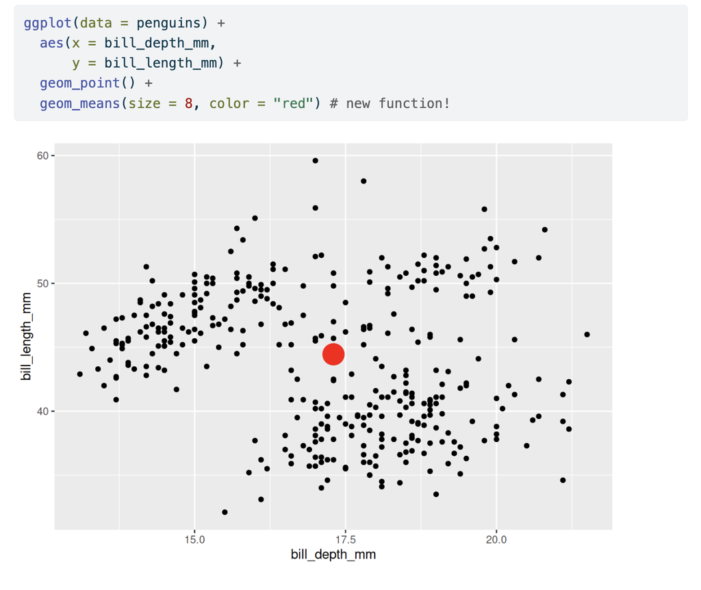

- A little bit of background…

The anatomy of ‘geom_point’…

```r
library(ggplot2)

geom_point
```

```
## function (mapping = NULL, data = NULL, stat = "identity", position = "identity",
##     ..., na.rm = FALSE, show.legend = NA, inherit.aes = TRUE)
## {
##     layer(mapping = mapping, data = data, geom = "point", stat = stat,
##         position = position, show.legend = show.legend, inherit.aes = inherit.aes,
##         params = list2(na.rm = na.rm, ...))
## }
## <bytecode: 0x11d53e7f0>
## <environment: 0x11d5337b0>
```

Actually has **three main ‘characters’** that specify the layer…

- Stat - precompute done prior to drawing (count, bin)
- Geom - a ‘mark’, the drawn thing… (point, bar, segment)
- Position - actually a *minor* character - cherry on top!! ‘Makes the marks dance’ - Hassan

[figure not shown]

[figure not shown]

[figure not shown]

geom_point: 1) StatIdentity, 2) GeomPoint, 3) position_identity()

- another example:

```r
geom_jitter
```

```
## function (mapping = NULL, data = NULL, stat = "identity", position = "jitter",
##     ..., width = NULL, height = NULL, na.rm = FALSE, show.legend = NA,
##     inherit.aes = TRUE)
## {
##     if (!missing(width) || !missing(height)) {
##         if (!missing(position)) {
##             cli::cli_abort(c("Both {.arg position} and {.arg width}/{.arg height} were supplied.",
##                 i = "Choose a single approach to alter the position."))
##         }
##         position <- position_jitter(width = width, height = height)
##     }
##     layer(data = data, mapping = mapping, stat = stat, geom = GeomPoint,
##         position = position, show.legend = show.legend, inherit.aes = inherit.aes,
##         params = list2(na.rm = na.rm, ...))
## }
## <bytecode: 0x11d7f5158>
## <environment: namespace:ggplot2>
```

geom_jitter: 1) StatIdentity, 2) GeomPoint, 3) position_jitter()

- Agenda build geom_means - which will draw a point at the means x and y for of observations (and do this group- and facet- wise - automatically)
- Step 0: Get the job done with base ggplot2!

```r
geom_histogram
```

```
## function (mapping = NULL, data = NULL, stat = "bin", position = "stack",
##     ..., binwidth = NULL, bins = NULL, orientation = NA, lineend = "butt",
##     linejoin = "mitre", na.rm = FALSE, show.legend = NA, inherit.aes = TRUE)
## {
##     layer(mapping = mapping, data = data, geom = "bar", stat = stat,
##         position = position, show.legend = show.legend, inherit.aes = inherit.aes,
##         params = list2(na.rm = na.rm, binwidth = binwidth, bins = bins,
##             orientation = orientation, lineend = lineend, linejoin = linejoin,
##             ...))
## }
## <bytecode: 0x11e0b8200>
## <environment: 0x11e0b5fd0>
```

geom_histogram: 1) StatBin, 2) GeomBar, 3) position_stack()

**Step 0:** Get the job done with base ggplot2 for reference…

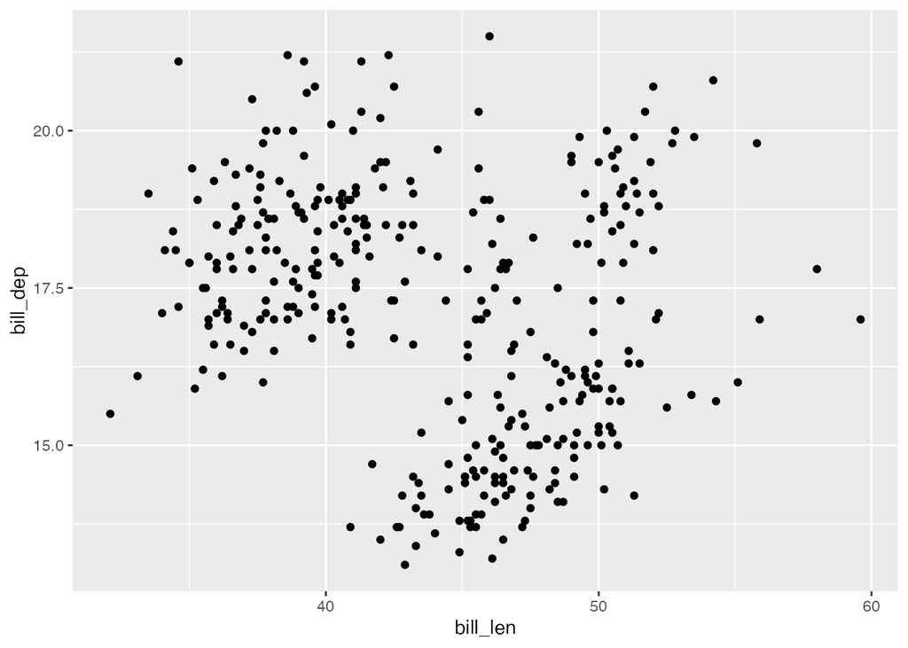

[figure not shown]

```r
penguins |>
  ggplot() +
  aes(x = bill_len,
      y = bill_dep) +
  geom_point()
```

**Step 1:** Define Compute. Test

[figure not shown]

**Step 2:** Define StatMeans. Test.

[figure not shown]

[figure not shown]

[figure not shown]

[figure not shown]

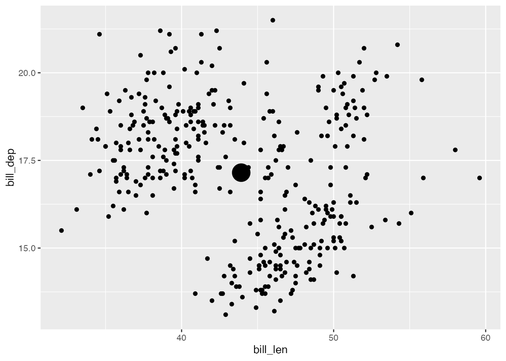

```r
# Test (and enjoy!!)
ggplot(penguins) +
  aes(bill_len, bill_dep) +
  geom_point() +
  geom_means(size = 8)
```

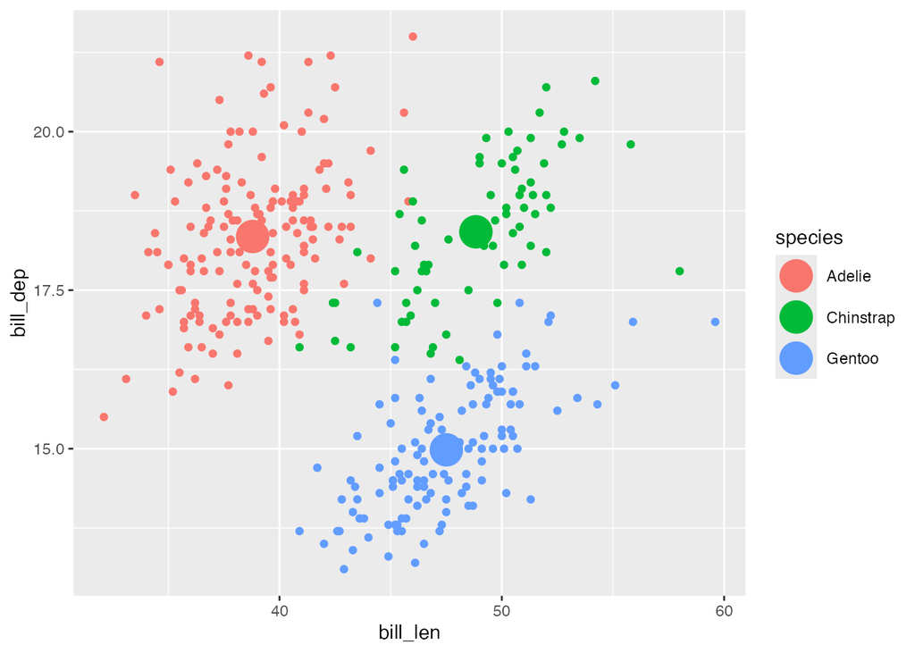

```r
# And enjoy group-wise behavior...
last_plot() +
  aes(color = species)
```

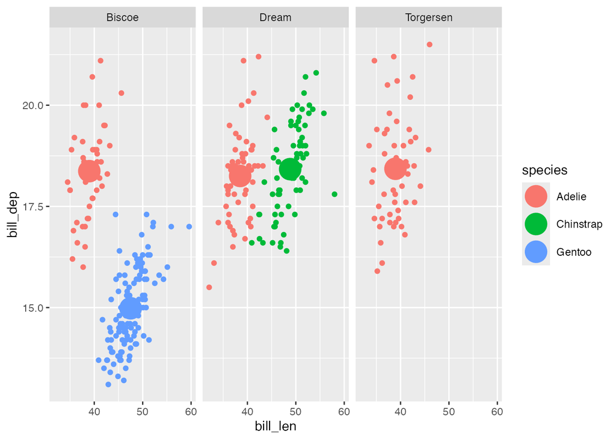

```r
last_plot() +
  facet_wrap(~island)
```

https://evamaerey.github.io/evamaerey/report2_easy_geom_recipes.pdf https://evamaerey.github.io/easy-geom-recipes/ https://has2k1.github.io/easy-geom-recipes/recipe1means.html

## But, I do love a monologue.

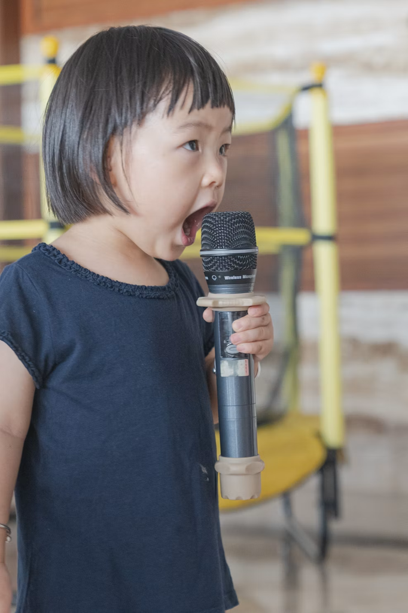

And monologues sometimes compress conversations, right?

> Many of [my New York Times] columns were the products of long telephone conversations with my friends - Anna Quindlen in ‘Living Out Loud’

We do monologues at ggplot2 extenders club (but like they are often pretty ‘hero’s journey’ stories - speaker talks about motivation and challenges… My eyes never glaze over during a hero’s journey story.)

And anyway, what I’d been thinking about for slides was a celebration of **visual conversation**, and that as motivation for ggplot2 extension.

So people like Thomas Lin Pedersen have talked about ggplot2 as enabling you to ‘Speak you plots into existence.’ And this sounds right, and powerful and awesome - just like ggplot2 is.

But, what I think is actually even more powerful and motivating for me is *conversing* with your data and recording that conversation - verbatim. *transcribing conversations you have with data* and transcribing the trains-of-thought you have with data.

Is ggplot2 can be kind-of a **transcriber** of human-data interactions… (if we let loose, and if we extend)

> ‘spontaneous language for conversation’

And I think many of us are thinking more and more about the power of language and conversation… Like because of LLMS, you may have been thinking, “like at what point did Natural Language emerge in the history of the universe, and why does it even work? How did we go from grunts to meaning” If I utter ‘potato’ does that conjure up in the mind the ‘potato’?

> “I could literally write anything and you’d read it …Think about your belly button. Boom, now you’r thinking about your belly button… That’s the power of writing. I love the power. I’m drunk on the stuff.” - Sarah Cooper, ‘Foolish’ 2023

Language is profoundly powerful.

Grammar is profoundly powerful.

Conversation is profoundly powerful.

I’m personally not so interested in a final, gorgeous plot, (though I’m often dazzled by them) or the pretty, reorganized ggplot2 syntax that you get after having arriving at a final viz product.

I *am* crazy about the conversations with data that ggplot2 allows!

It’s great that ggplot2 syntax can be concise, but I am a bigger fan of the fact that ‘inconcision’ is permitted, that lets us record ideas *practically verbatim*. (Like the Data Science Lab conversations transcripts!)

> ‘Ums’ and ‘Uhs’ tend to occur when we are doing really hard cognative lifting … to kind of give us a processing moment … with Valerie Fridland, author of ‘Like, Literally, Dude.’ thinking about inconcision as functional.

So… that was a huge monologue for someone who says they are crazy about conversation. 😂

# Native inconsicion in ggplot2

```r
library(tidyverse)
```

Here’s the sanctioned way of doing things…

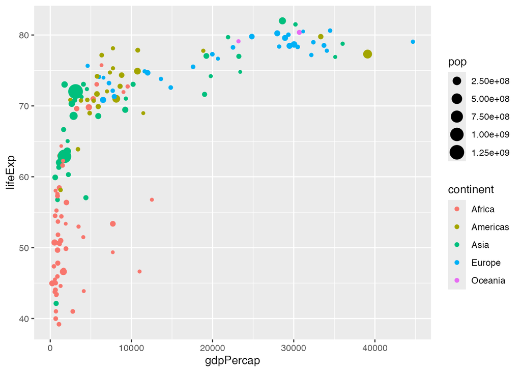

| ggplot() + |
| --- |
| stamp_png(png = hans_png_path_y_axis) + |
| stamp_png(png = hans_png_path_x_axis) + |
| stamp_png(png = hans_png_path_color) + |
| stamp_png(png = hans_png_path_size) + |
| stamp_label(label = lab, size = 10) |

[figure not shown]

```r
gapminder::gapminder |>
  filter(year == 2002) |>
  ggplot(aes(x = gdpPercap,
             y = lifeExp,
             color = continent,
             size = pop)) +
  geom_point()
```

https://www.youtube.com/watch?v=jbkSRLYSojo&t=37s

| ggplot(filter(gapminder::gapminder, year == 2002)) + |
| --- |
| ggchalkboard:::theme_rosling() + |
| aes(y = lifeExp) + |
| aes(x = gdpPercap) + |
| geom_point() + |
| aes(color = continent) + |
| aes(size = pop) |

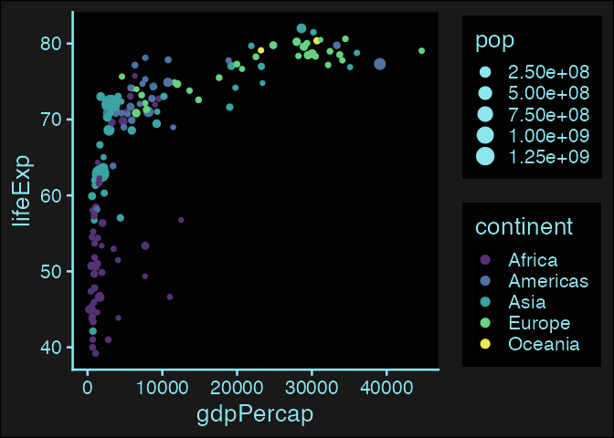

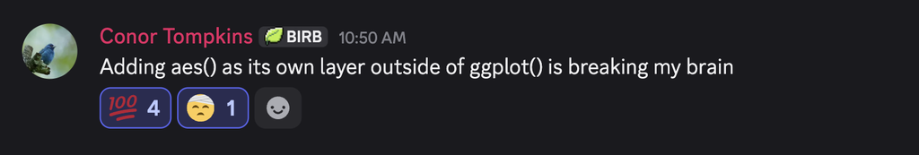

[figure not shown]

Ick…

[figure not shown]

Yuck…

# ‘Data visualization is right at the heart of my work.’ - Hans Rosling’s introduction to ‘200 Countries, 200 Years, 4 Minutes - The Joy of Stats - BBC’

# And aesthetic mapping is right at the heart to data visualization - is

> it so wrong to want those decisions to get **full voice**?

[figure not shown]

Bear of very little brain…

# Lightly wrapped inconcision: ggkids (maybe this is okay for kids)

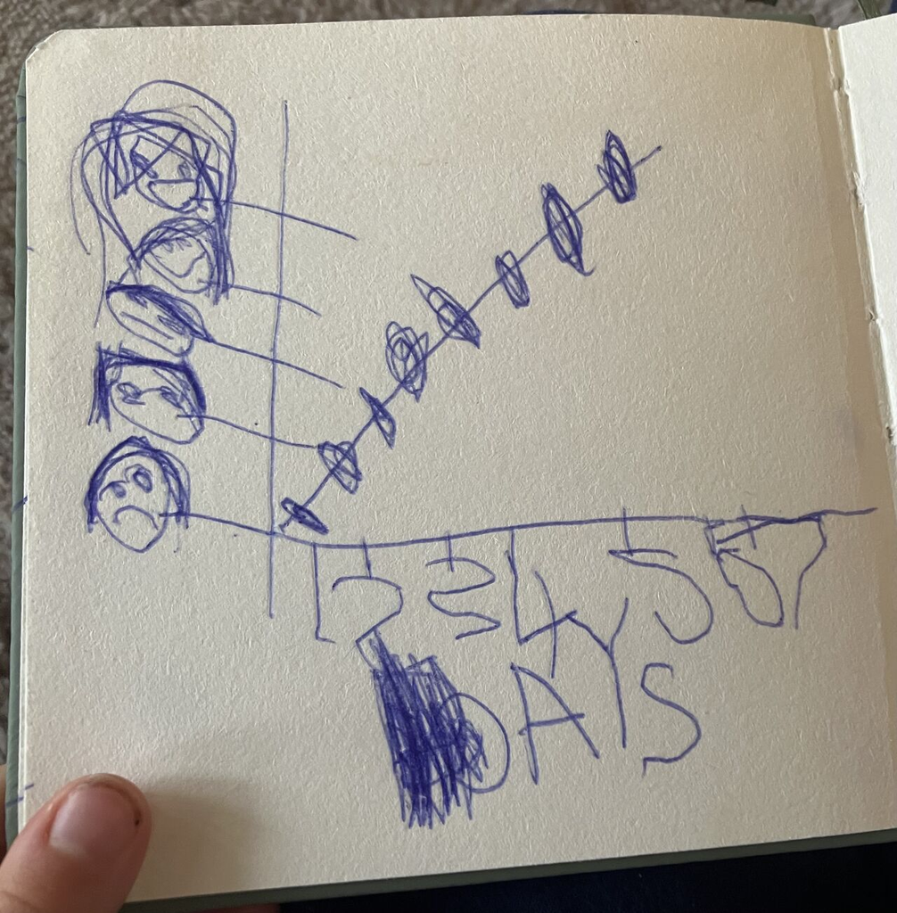

Tim Baller’s Daugher…

```r
library(ggkids)

repair_data <-
   write_table(~days, ~feeling,
                1,      "😩",
                2,      "😞",
                3,      "😕",
                4,      "😐",
                5,      "😏",
                6,      "😊",
                7,      "😁")
```

| ggkids(data = repair_data) + |
| --- |
| use_x(days) + |
| use_y(feeling) + |
| chart_point() + |
| chart_line() + |
| scale_x_counting() + |
| theme_kids(ink = "midnightblue") |

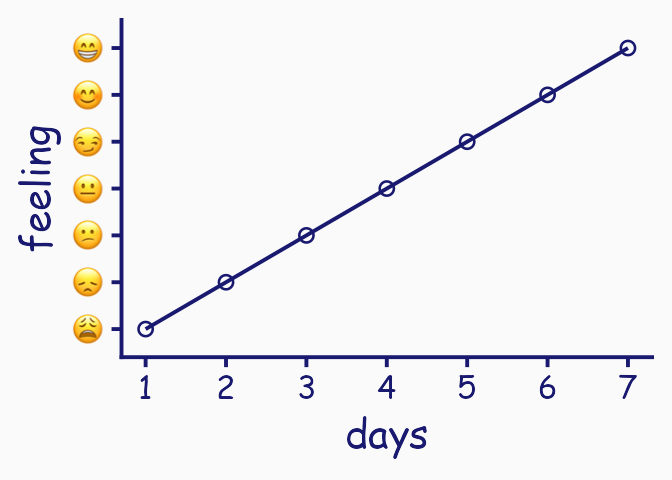

# Long form poems… Transcribing statistical narratives…

Extension and statistical narratives …

2020: Stats instructor teaching “Introduction to Statistical Investigations”

[figure not shown]

loved,

–

but… missed coded workflow (there was some, but less that I’d have liked)

There’s something really grounding (and powerful? 3400 to 3100 BCE) about going back to a code narrative, being able to review the steps of what you did.

(quotes from Winston, Paul)

> You know people were doing their statistics most of the people in my department were using SPSS um and I found that very confusing SPSS you know quote syntax um where they it provides some code to do your analysis, you’d um you know you’d bring in your data and you’d um you click some buttons and you’d check some boxes for turning

> Some instructors may train students in using a specific software package, but mastery of advanced programming skills should not be allowed to crowd out data analysis skills or statistical thinking.

Could we have the best of both worlds?

> ‘Schreiben ist wichtig’… Writing is important - Herr Heineke

Could we do what we were doing on *chalkboards* (love a chalk board!! analogue gold standard), but also do that w/ code, consistent w/ the touch of ggplot2 students were learning anyway, and code that would serve the concepts being learned instead of shoehorning functions around the statistical narrative.

Chalkboard version went like this…

| ggplot(donor_data) + |
| --- |
| labs(title = "🫀🫁Donor Y/N response 50/50?") + |
| aes(x = decision) + |
| geom_stack() + |
| geom_stack_label() + |
| geom_support() + |
| geom_prop() + |
| geom_prop_label() + |
| stamp_prop(0.5) + |
| geom_binomial_null() + |
| geom_normal_prop_null() + |
| geom_normal_prop_null_sds() + |
| stamp_eq_norm_prop() + |
| labs(caption = "isi-stats.com") |

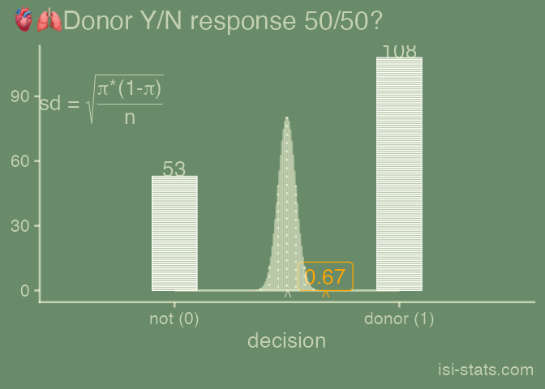

| ggplot(dolphin_data) + |
| --- |
| labs(title = "Can 🐬Doris & 🐬Buzz communicate? 🐟🪣") + |
| aes(x = observed) + |
| geom_stack() + |
| geom_stack_label() + |
| geom_support() + |
| geom_prop() + |
| geom_prop_label() + |
| stamp_prop(0.5) + |
| geom_binomial_null() + |
| labs(caption = "isi-stats.com") |

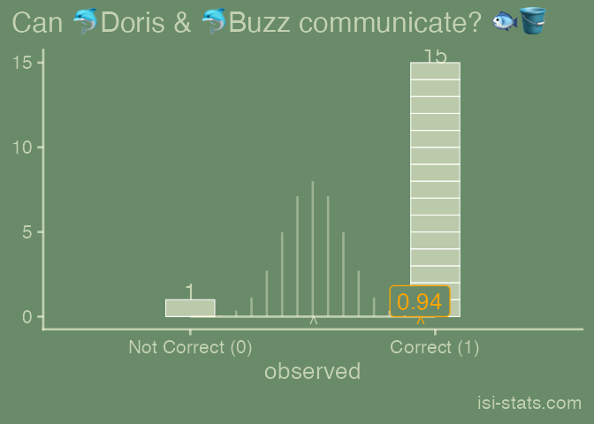

| ggplot(scissors_data) + |
| --- |
| labs(title = "🪨📃✂️ Preference away from Scissors?") + |
| aes(x = thrown) + |
| geom_stack() + |
| geom_stack_label() + |
| geom_support() + |
| geom_prop() + |
| geom_prop_label() + |
| stamp_prop(0.333) + |
| geom_binomial_null(prob = 0.333) + |
| labs(caption = "isi-stats.com") |

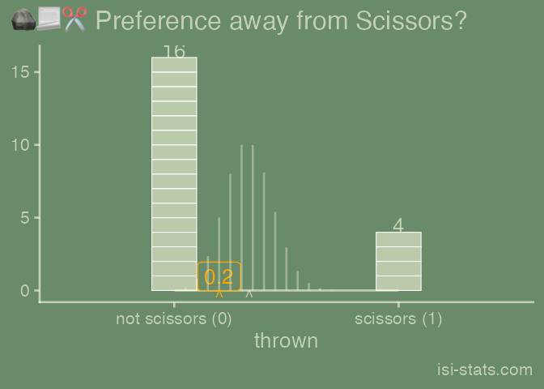

| ggplot(data_grit_undergrad) + |
| --- |
| labs(title = "🪖😬💪🧗🏽‍♂️ Gritty as West Point Cadets?") + |
| aes(x = score) + |
| geom_stacks() + |
| geom_support() + |
| geom_mean() + |
| geom_mean_label() + |
| stamp_mean(3.75) + |
| stamp_mean_label(3.75) + |
| geom_tdist_null(value = 3.75) + |
| labs(caption = "Duckworth et al. 2007, Grit...") |

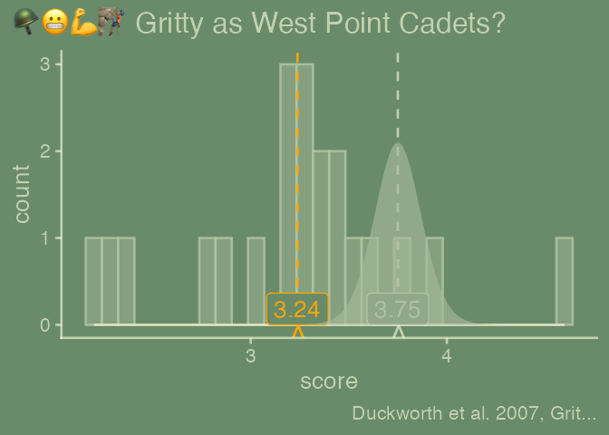

| ggplot(cars) + |
| --- |
| labs(title = "🚙 Cars data - stopping distance") + |
| aes(x = speed, y = dist) + |
| geom_point() + |
| geom_lm() + |
| geom_lm(y ~ 1) + |
| geom_lm_fitted() + |
| geom_lm_residuals() + |
| geom_lm_conf_int() + |
| geom_lm_pred_int() + |
| geom_lm_intercept() + |
| geom_lm_intercept_label() + |
| geom_lm_formula() + |
| labs(caption = "R Core Team (2025) datasets") |

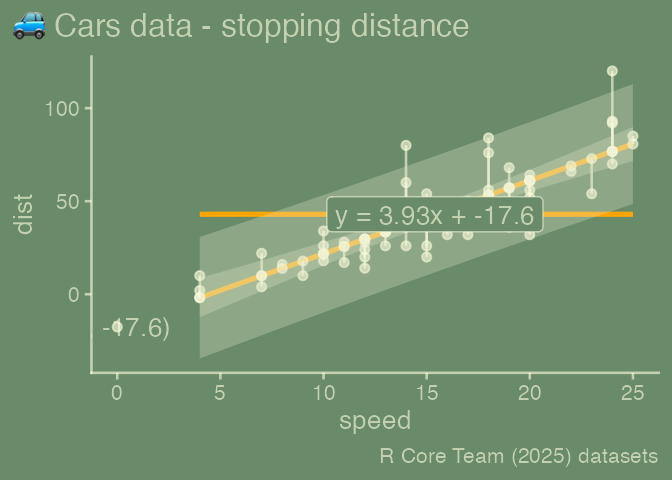

So the motivation today, is to show you some ggplot2 extension moves - but also to think about how we can create new vocabulary to *write down* the statistical narratives that we are telling all the time - be it in the classroom or elsewhere - with greater precision and using new bespoke vocabulary (functions) if needed.

Isn’t this like a lot of effort to be able to ‘write down a statistical poem’ something down?

Why don’t we just have students use base ggplot2, and do the wrangling/calculations by hand?

> Some instructors may train students in using a specific software package, but *mastery of advanced programming skills should not be allowed to crowd out data analysis skills or statistical thinking.*

> Mastry of the minutia of ggplot2 and data manipulation and should not be allowed to crowd out statistical thinking.

Leland McInnes’ (UMAP dimentionality reduction technique) red star…

> necessarily particular details of how any given technique works so that means I’m going to introduce a little bit of extra notation which is gonna be really useful repeatedly and that’s the red star. So sometimes technical details

really really matter but they’re not worth getting into because by the time you’ve explained all the technical details you have lost the point of what you are trying to explain in the first place so if I just want the big picture idea 1:22 and there are some technical details that make that statement not technically true but morally it’s the right thing

> the goldilocks situation: Write it, and don’t loose the train of thought by bespoke packages like ggprop.test, ggt.test. ggols…

Huge audiences:

1000 cadets every year…

EAPOST - network of 600 instructors…

100000 AP stats high school students per year

–